# Computer lab 1 block 1

732A99

Duc Tran

William Wiik

Sigme

09 november 2023

# Assignment 3. Logistic regression and basis function expansion

## Data

The data contains information about the onset of diabetes within 5 years in Pima Indians given medical details. The variables are:

- Number of times pregnant
- Plasma glucose concentration a 2 hours in an oral glucose tolerance test.
- Diastolic blood pressure (mm Hg).
- Triceps skinfold thickness (mm).
- 2-Hour serum insulin (mu U/ml).
- Body mass index (weight in kg/(height in m)^2).
- Diabetes pedigree function.
- Age (years).
- Diabetes (0=no or 1=yes).

```r
diabetes_df <- read.csv("pima-indians-diabetes.csv", header=FALSE)

colnames(diabetes_df) <- c("times_pregnant", "plasma_glucose_conc",
                        "diastolic_blood_pressure", "triceps_skinfold_thickness",
                        "serum_insulin","body_mass_index", "diabetes_pedigree",
                        "age", "diabetes")

diabetes_df$diabetes <- ifelse(diabetes_df$diabetes == 0, "no", "yes")
diabetes_df$diabetes <- as.factor(diabetes_df$diabetes)
```

## 3.1

**Question:** Make a scatterplot showing a Plasma glucose concentration on Age where observations are colored by Diabetes levels.

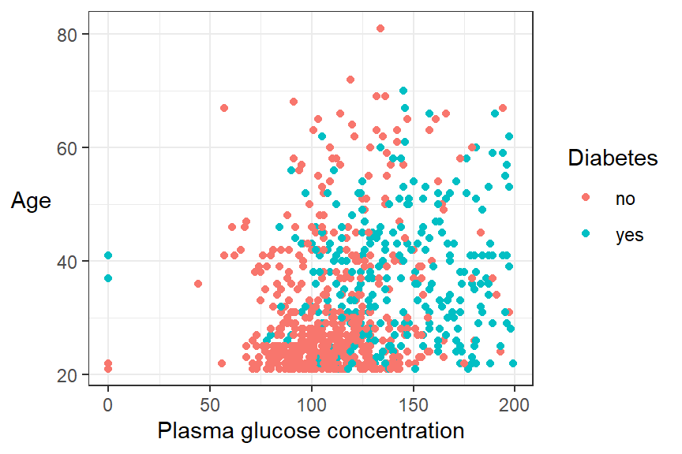

```r
library(ggplot2)

ggplot(diabetes_df, aes(x = plasma_glucose_conc, y = age, color = diabetes)) +
  geom_point() +
  theme_bw() +
  theme(axis.title.y = element_text(angle = 0,vjust = 0.5)) +
  labs(colour = "Diabetes",
       x = "Plasma glucose concentration",
       y = "Age")
```

**Question:** Do you think that Diabetes is easy to classify by a standard logistic regression model that uses these two variables as features? Motivate your answer.

## 3.2

**Question:**

Train a logistic regression model with $y$ = Diabetes as target $x_1$ = Plasma glucose concentration and $x_2$ = Age as features and make a prediction for all observations by using $r$ = 0.5 as the classification threshold. Report the probabilistic equation of the estimated model and compute also the training misclassification error.

```r
model <- glm(diabetes ~ plasma_glucose_conc + age, data = diabetes_df,
             family =  "binomial")

pred <- predict(model, newdata = diabetes_df, type = "response")

# Using 0.5 as the classification threshold
pred <- ifelse(pred > 0.5, "yes", "no")

confusion <- table(diabetes_df$diabetes, pred)
misclass_rate <- (confusion[1,2] + confusion[2,1]) / sum(confusion)


knitr::kable(as.data.frame(round(misclass_rate,2)), col.names = "Misclassification error",
             caption = "Misclassification error")
```

Misclassification error

| Misclassification error |
| --- |
| 0.26 |

**Question:**

Make a scatter plot of the same kind as in step 1 but showing the predicted values of Diabetes as a color instead.

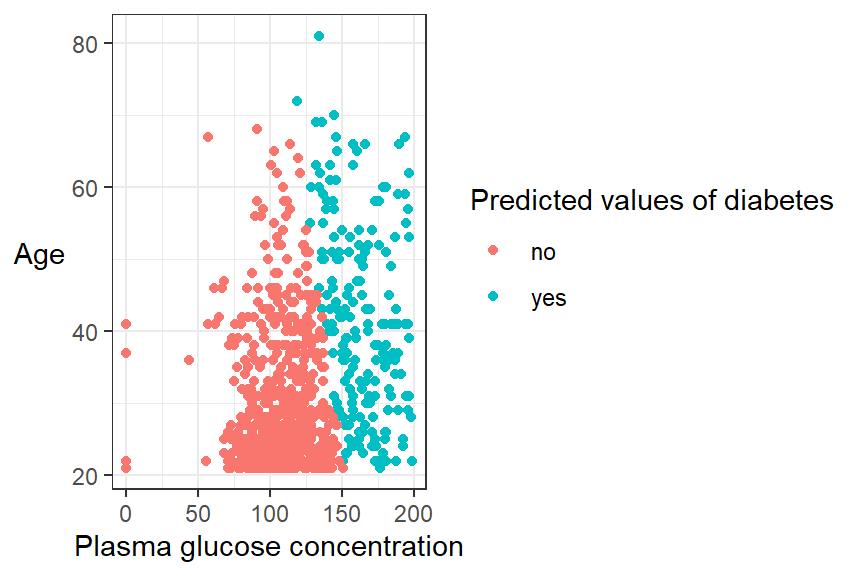

```r
diabetes_df_pred <- diabetes_df
diabetes_df_pred$pred <- pred

ggplot(diabetes_df_pred, aes(x = plasma_glucose_conc, y = age, color = pred)) +
  geom_point() +
  theme_bw() +
  theme(axis.title.y = element_text(angle = 0,vjust = 0.5)) +
  labs(colour = "Predicted values of diabetes",
       x = "Plasma glucose concentration",
       y = "Age")
```

**Question:**

Comment on the quality of the classification by using these results.

## 3.3

**Question:**

Use the model estimated in step 2 to a) report the equation of the decision boundary between the two classes b) add a curve showing this boundary to the scatter plot in step 2.

```r
summary(model)
```

```
##
## Call:
## glm(formula = diabetes ~ plasma_glucose_conc + age, family = "binomial",
##     data = diabetes_df)
##
## Coefficients:
##                      Estimate Std. Error z value Pr(>|z|)
## (Intercept)         -5.912449   0.462620  -12.78  < 2e-16 ***
## plasma_glucose_conc  0.035644   0.003290   10.83  < 2e-16 ***
## age                  0.024778   0.007374    3.36 0.000778 ***
## ---
## Signif. codes:  0 '***' 0.001 '**' 0.01 '*' 0.05 '.' 0.1 ' ' 1
##
## (Dispersion parameter for binomial family taken to be 1)
##
##     Null deviance: 993.48  on 767  degrees of freedom
## Residual deviance: 797.36  on 765  degrees of freedom
## AIC: 803.36
##
## Number of Fisher Scoring iterations: 4
```

```r
slope <- coef(model)[2]/(-coef(model)[3])
intercept <- coef(model)[1]/(-coef(model)[3])


diabetes_df
```

[output not shown]

[output cut: 758 more lines]

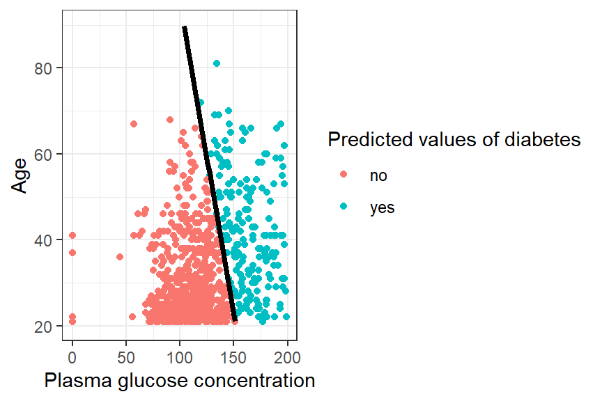

```r
 #coef(model)[1] + t(as.matrix(coef(model)[2:3])) %*% as.matrix(diabetes_df[,c("plasma_glucose_conc","age")])

ggplot(diabetes_df_pred, aes(x = plasma_glucose_conc, y = age, color = pred)) +
  geom_point() +
  theme_bw() +
 stat_function(fun = ({function(x) (-coef(model)[1] - coef(model)[2]*x)/ coef(model)[3] }),
               size=1.5, color = "black") +
  ylim(20,90) +
  labs(colour = "Predicted values of diabetes",
       x = "Plasma glucose concentration",
       y = "Age")
```

**Question:**

Comment whether the decision boundary seems to catch the data distribution well.

## 3.4

**Question:**

Make same kind of plots as in step 2 but use thresholds $r$ = 0.2 and $r$ = 0.8. By using these plots

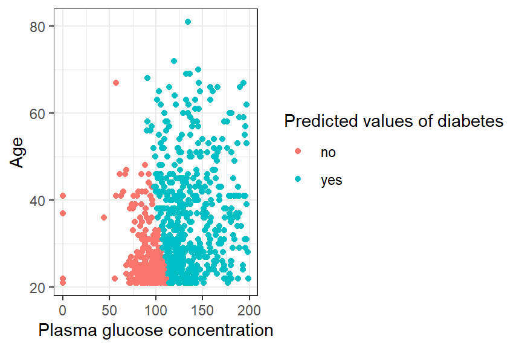

```r
# Using 0.2 as the classification threshold
pred <- predict(model, newdata = diabetes_df, type = "response")
pred <- ifelse(pred > 0.2, "yes", "no")
diabetes_df_pred$pred <- pred


p1 <- ggplot(diabetes_df_pred, aes(x = plasma_glucose_conc, y = age, color = pred)) +
      geom_point() +
      theme_bw() +
      labs(colour = "Predicted values of diabetes",
           x = "Plasma glucose concentration",
           y = "Age")


# Using 0.8 as the classification threshold
pred <- predict(model, newdata = diabetes_df, type = "response")
pred <- ifelse(pred > 0.8, "yes", "no")
diabetes_df_pred$pred <- pred


p2 <- ggplot(diabetes_df_pred, aes(x = plasma_glucose_conc, y = age, color = pred)) +
      geom_point() +
      theme_bw() +
      labs(colour = "Predicted values of diabetes",
           x = "Plasma glucose concentration",
           y = "Age")

par(mfrow=c(2,1))
plot(p1)
```

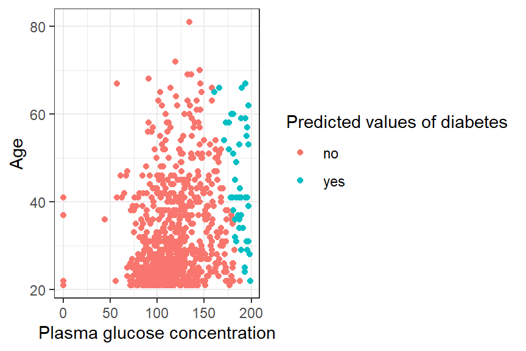

```r
plot(p2)
```

**Question:**

Comment on what happens with the prediction when $r$ value changes.

## 3.5

**Question:**